# Project: Investigate a Dataset - No-Show Appointments

- Introduction
- Data Wrangling
- Exploratory Data Analysis
- Conclusions

## Introduction

### Dataset Description

This dataset looks at whether or not patient's show up to their appointments, and factors that could impact that. It is taken from the medical information of 100k appointments made in Brazil.

**Columns**

`PatientId` - An ID number for each patient \ `AppointmentId` - An ID number for each appointment\ `Gender` - Gender of patient\ `ScheduledDay` - Date and time the appointment was made\ `AppointmentDay` - Date of appointment\ `Age` - Age of patient\ `Neighbourhood` - Town of hospital\ `Scholarship` - Whether or not patient is enrolled in Bolsa Familia\ `Hipertension` - Whether or not patient has hypertension\ `Diabetes` - Whether or not patient is diabetic\ `Alcoholism` - Whether or not patient is an alcoholic\ `Handcap` - Whther or not patient is handicap\ `SMS_received` - If the patient received an SMS message about the appointment\ `No-show` - If the patient is a no show, 'No' means the patient showed up to the appointment\

### Question(s) for Analysis

**Question 1** \ How frequently do patients not show up?

**Question 2** \ Which factors correlate most to a patient not showing up?

**Question 3**\ What does the average no show patient look like?

```python
import pandas as pd
import numpy as np
import seaborn as sns
import matplotlib.pyplot as plt
import datetime as dt

pd.options.mode.chained_assignment = None
```

## Data Wrangling

### General Properties

```python
df = pd.read_csv('KaggleV2-May-2016.csv')
df
```

|  | PatientId | AppointmentID | Gender | ScheduledDay | AppointmentDay | Age | Neighbourhood | Scholarship | Hipertension | Diabetes | Alcoholism | Handcap | SMS_received | No-show |
| --- | --- | --- | --- | --- | --- | --- | --- | --- | --- | --- | --- | --- | --- | --- |
| 0 | 2.987250e+13 | 5642903 | F | 2016-04-29T18:38:08Z | 2016-04-29T00:00:00Z | 62 | JARDIM DA PENHA | 0 | 1 | 0 | 0 | 0 | 0 | No |
| 1 | 5.589978e+14 | 5642503 | M | 2016-04-29T16:08:27Z | 2016-04-29T00:00:00Z | 56 | JARDIM DA PENHA | 0 | 0 | 0 | 0 | 0 | 0 | No |
| 2 | 4.262962e+12 | 5642549 | F | 2016-04-29T16:19:04Z | 2016-04-29T00:00:00Z | 62 | MATA DA PRAIA | 0 | 0 | 0 | 0 | 0 | 0 | No |
| 3 | 8.679512e+11 | 5642828 | F | 2016-04-29T17:29:31Z | 2016-04-29T00:00:00Z | 8 | PONTAL DE CAMBURI | 0 | 0 | 0 | 0 | 0 | 0 | No |
| 4 | 8.841186e+12 | 5642494 | F | 2016-04-29T16:07:23Z | 2016-04-29T00:00:00Z | 56 | JARDIM DA PENHA | 0 | 1 | 1 | 0 | 0 | 0 | No |
| ... | ... | ... | ... | ... | ... | ... | ... | ... | ... | ... | ... | ... | ... | ... |
| 110522 | 2.572134e+12 | 5651768 | F | 2016-05-03T09:15:35Z | 2016-06-07T00:00:00Z | 56 | MARIA ORTIZ | 0 | 0 | 0 | 0 | 0 | 1 | No |
| 110523 | 3.596266e+12 | 5650093 | F | 2016-05-03T07:27:33Z | 2016-06-07T00:00:00Z | 51 | MARIA ORTIZ | 0 | 0 | 0 | 0 | 0 | 1 | No |
| 110524 | 1.557663e+13 | 5630692 | F | 2016-04-27T16:03:52Z | 2016-06-07T00:00:00Z | 21 | MARIA ORTIZ | 0 | 0 | 0 | 0 | 0 | 1 | No |
| 110525 | 9.213493e+13 | 5630323 | F | 2016-04-27T15:09:23Z | 2016-06-07T00:00:00Z | 38 | MARIA ORTIZ | 0 | 0 | 0 | 0 | 0 | 1 | No |
| 110526 | 3.775115e+14 | 5629448 | F | 2016-04-27T13:30:56Z | 2016-06-07T00:00:00Z | 54 | MARIA ORTIZ | 0 | 0 | 0 | 0 | 0 | 1 | No |

110527 rows × 14 columns

```python
df.dtypes
```

```
PatientId         float64
AppointmentID       int64
Gender             object
ScheduledDay       object
AppointmentDay     object
Age                 int64
Neighbourhood      object
Scholarship         int64
Hipertension        int64
Diabetes            int64
Alcoholism          int64
Handcap             int64
SMS_received        int64
No-show            object
dtype: object
```

```python
df.duplicated().value_counts().reset_index()
```

|  | index | count |
| --- | --- | --- |
| 0 | False | 110527 |

There are no duplicate rows

```python
df.isnull().value_counts().reset_index()
```

|  | PatientId | AppointmentID | Gender | ScheduledDay | AppointmentDay | Age | Neighbourhood | Scholarship | Hipertension | Diabetes | Alcoholism | Handcap | SMS_received | No-show | count |
| --- | --- | --- | --- | --- | --- | --- | --- | --- | --- | --- | --- | --- | --- | --- | --- |
| 0 | False | False | False | False | False | False | False | False | False | False | False | False | False | False | 110527 |

```python
df.describe()
```

|  | PatientId | AppointmentID | Age | Scholarship | Hipertension | Diabetes | Alcoholism | Handcap | SMS_received |
| --- | --- | --- | --- | --- | --- | --- | --- | --- | --- |
| count | 1.105270e+05 | 1.105270e+05 | 110527.000000 | 110527.000000 | 110527.000000 | 110527.000000 | 110527.000000 | 110527.000000 | 110527.000000 |
| mean | 1.474963e+14 | 5.675305e+06 | 37.088874 | 0.098266 | 0.197246 | 0.071865 | 0.030400 | 0.022248 | 0.321026 |
| std | 2.560949e+14 | 7.129575e+04 | 23.110205 | 0.297675 | 0.397921 | 0.258265 | 0.171686 | 0.161543 | 0.466873 |
| min | 3.921784e+04 | 5.030230e+06 | -1.000000 | 0.000000 | 0.000000 | 0.000000 | 0.000000 | 0.000000 | 0.000000 |
| 25% | 4.172614e+12 | 5.640286e+06 | 18.000000 | 0.000000 | 0.000000 | 0.000000 | 0.000000 | 0.000000 | 0.000000 |
| 50% | 3.173184e+13 | 5.680573e+06 | 37.000000 | 0.000000 | 0.000000 | 0.000000 | 0.000000 | 0.000000 | 0.000000 |
| 75% | 9.439172e+13 | 5.725524e+06 | 55.000000 | 0.000000 | 0.000000 | 0.000000 | 0.000000 | 0.000000 | 1.000000 |
| max | 9.999816e+14 | 5.790484e+06 | 115.000000 | 1.000000 | 1.000000 | 1.000000 | 1.000000 | 4.000000 | 1.000000 |

There is no missing information

### Data Cleaning

The data is already fairly clean. The `PatientId` column is presented in e notation, which can be fixed by formatting the column. The `ScheduledDay` and `AppointmentDay` columns include both date and time, so they should be split to seperate columns for better analysis, as I will not require the times. The dates will then need to be converted to the proper date format. The `No-Show` column should be changed from categorical to numeric by using a `lambda` function to convert `Yes` to `1` and `No` to `0`. When using `describe` on the dataframe, I noticed potential outilers in the `Age` column, as well as ages under `0`. I will check for and remove outliers.

```python
df['PatientId'] = df['PatientId'].apply(lambda x: '{:.0f}'.format(x))
```

This `lambda` function reformats `PatientId`

```python
def split_date(column,new_names):
    df[new_names] = df[column].str.split('T',expand=True)
    return df

df = split_date('ScheduledDay',['ScheduledDay','ScheduledTime'])
df = split_date('AppointmentDay',['AppointmentDay','AppointmentTime'])

df
```

|  | PatientId | AppointmentID | Gender | ScheduledDay | AppointmentDay | Age | Neighbourhood | Scholarship | Hipertension | Diabetes | Alcoholism | Handcap | SMS_received | No-show | ScheduledTime | AppointmentTime |
| --- | --- | --- | --- | --- | --- | --- | --- | --- | --- | --- | --- | --- | --- | --- | --- | --- |
| 0 | 29872499824296 | 5642903 | F | 2016-04-29 | 2016-04-29 | 62 | JARDIM DA PENHA | 0 | 1 | 0 | 0 | 0 | 0 | No | 18:38:08Z | 00:00:00Z |
| 1 | 558997776694438 | 5642503 | M | 2016-04-29 | 2016-04-29 | 56 | JARDIM DA PENHA | 0 | 0 | 0 | 0 | 0 | 0 | No | 16:08:27Z | 00:00:00Z |
| 2 | 4262962299951 | 5642549 | F | 2016-04-29 | 2016-04-29 | 62 | MATA DA PRAIA | 0 | 0 | 0 | 0 | 0 | 0 | No | 16:19:04Z | 00:00:00Z |
| 3 | 867951213174 | 5642828 | F | 2016-04-29 | 2016-04-29 | 8 | PONTAL DE CAMBURI | 0 | 0 | 0 | 0 | 0 | 0 | No | 17:29:31Z | 00:00:00Z |
| 4 | 8841186448183 | 5642494 | F | 2016-04-29 | 2016-04-29 | 56 | JARDIM DA PENHA | 0 | 1 | 1 | 0 | 0 | 0 | No | 16:07:23Z | 00:00:00Z |
| ... | ... | ... | ... | ... | ... | ... | ... | ... | ... | ... | ... | ... | ... | ... | ... | ... |
| 110522 | 2572134369293 | 5651768 | F | 2016-05-03 | 2016-06-07 | 56 | MARIA ORTIZ | 0 | 0 | 0 | 0 | 0 | 1 | No | 09:15:35Z | 00:00:00Z |
| 110523 | 3596266328735 | 5650093 | F | 2016-05-03 | 2016-06-07 | 51 | MARIA ORTIZ | 0 | 0 | 0 | 0 | 0 | 1 | No | 07:27:33Z | 00:00:00Z |
| 110524 | 15576631729893 | 5630692 | F | 2016-04-27 | 2016-06-07 | 21 | MARIA ORTIZ | 0 | 0 | 0 | 0 | 0 | 1 | No | 16:03:52Z | 00:00:00Z |
| 110525 | 92134931435557 | 5630323 | F | 2016-04-27 | 2016-06-07 | 38 | MARIA ORTIZ | 0 | 0 | 0 | 0 | 0 | 1 | No | 15:09:23Z | 00:00:00Z |
| 110526 | 377511518121127 | 5629448 | F | 2016-04-27 | 2016-06-07 | 54 | MARIA ORTIZ | 0 | 0 | 0 | 0 | 0 | 1 | No | 13:30:56Z | 00:00:00Z |

110527 rows × 16 columns

The function `split_date` is used to split `ScheduledDay` and `AppointmetDay` into seperate day and time columns

```python
df[['AppointmentDay','ScheduledDay']]=df[['AppointmentDay','ScheduledDay']].apply(lambda x: pd.to_datetime(x).dt.normalize())
df.dtypes
```

```
PatientId                  object
AppointmentID               int64
Gender                     object
ScheduledDay       datetime64[ns]
AppointmentDay     datetime64[ns]
Age                         int64
Neighbourhood              object
Scholarship                 int64
Hipertension                int64
Diabetes                    int64
Alcoholism                  int64
Handcap                     int64
SMS_received                int64
No-show                    object
ScheduledTime              object
AppointmentTime            object
dtype: object
```

This `lambda` function is used to convert the day columns to the proper datetime format.

```python
df['No_show'] = df['No-show'].apply(lambda x: 1 if x == 'Yes' else 0)
df['Shows_up'] = df['No-show'].apply(lambda x: 1 if x == 'No' else 0)
df
```

|  | PatientId | AppointmentID | Gender | ScheduledDay | AppointmentDay | Age | Neighbourhood | Scholarship | Hipertension | Diabetes | Alcoholism | Handcap | SMS_received | No-show | ScheduledTime | AppointmentTime | No_show | Shows_up |
| --- | --- | --- | --- | --- | --- | --- | --- | --- | --- | --- | --- | --- | --- | --- | --- | --- | --- | --- |
| 0 | 29872499824296 | 5642903 | F | 2016-04-29 | 2016-04-29 | 62 | JARDIM DA PENHA | 0 | 1 | 0 | 0 | 0 | 0 | No | 18:38:08Z | 00:00:00Z | 0 | 1 |
| 1 | 558997776694438 | 5642503 | M | 2016-04-29 | 2016-04-29 | 56 | JARDIM DA PENHA | 0 | 0 | 0 | 0 | 0 | 0 | No | 16:08:27Z | 00:00:00Z | 0 | 1 |
| 2 | 4262962299951 | 5642549 | F | 2016-04-29 | 2016-04-29 | 62 | MATA DA PRAIA | 0 | 0 | 0 | 0 | 0 | 0 | No | 16:19:04Z | 00:00:00Z | 0 | 1 |
| 3 | 867951213174 | 5642828 | F | 2016-04-29 | 2016-04-29 | 8 | PONTAL DE CAMBURI | 0 | 0 | 0 | 0 | 0 | 0 | No | 17:29:31Z | 00:00:00Z | 0 | 1 |
| 4 | 8841186448183 | 5642494 | F | 2016-04-29 | 2016-04-29 | 56 | JARDIM DA PENHA | 0 | 1 | 1 | 0 | 0 | 0 | No | 16:07:23Z | 00:00:00Z | 0 | 1 |
| ... | ... | ... | ... | ... | ... | ... | ... | ... | ... | ... | ... | ... | ... | ... | ... | ... | ... | ... |
| 110522 | 2572134369293 | 5651768 | F | 2016-05-03 | 2016-06-07 | 56 | MARIA ORTIZ | 0 | 0 | 0 | 0 | 0 | 1 | No | 09:15:35Z | 00:00:00Z | 0 | 1 |
| 110523 | 3596266328735 | 5650093 | F | 2016-05-03 | 2016-06-07 | 51 | MARIA ORTIZ | 0 | 0 | 0 | 0 | 0 | 1 | No | 07:27:33Z | 00:00:00Z | 0 | 1 |
| 110524 | 15576631729893 | 5630692 | F | 2016-04-27 | 2016-06-07 | 21 | MARIA ORTIZ | 0 | 0 | 0 | 0 | 0 | 1 | No | 16:03:52Z | 00:00:00Z | 0 | 1 |
| 110525 | 92134931435557 | 5630323 | F | 2016-04-27 | 2016-06-07 | 38 | MARIA ORTIZ | 0 | 0 | 0 | 0 | 0 | 1 | No | 15:09:23Z | 00:00:00Z | 0 | 1 |
| 110526 | 377511518121127 | 5629448 | F | 2016-04-27 | 2016-06-07 | 54 | MARIA ORTIZ | 0 | 0 | 0 | 0 | 0 | 1 | No | 13:30:56Z | 00:00:00Z | 0 | 1 |

110527 rows × 18 columns

These `lambda` functions convert the `No-Show` column into two columns that demonstrate whether or not a patient showd up using `1` and `0`.

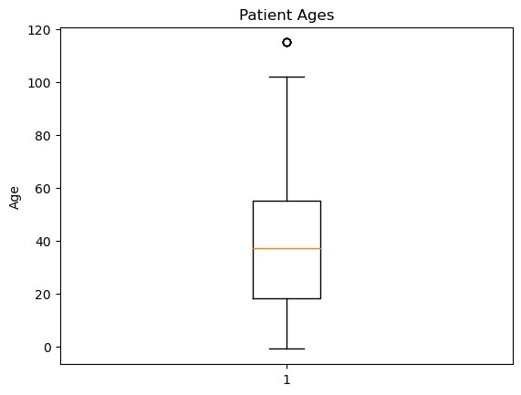

```python
plt.boxplot(df['Age'])
plt.title('Patient Ages')
plt.ylabel('Age')
plt.show()
```

This boxplot shows that there are outliers in the `Age` column

```python
q1, q3 = np.percentile(df['Age'], [25,75])
IQR = q3 - q1
```

To remove outliers, first I find the IQR

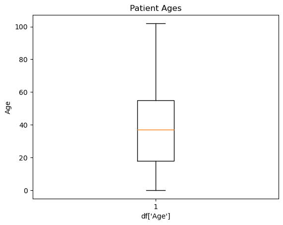

```python
df = df[(df['Age'] >= 0) & (df['Age'] <= (q3 + (1.5*IQR)))]
plt.boxplot(df['Age'])
plt.title('Patient Ages')
plt.ylabel('Age')
plt.xlabel("df['Age']")
plt.show()
```

I removed all ages below `0` and used the IQR to remove upper outliers

```python
df = df[['PatientId','Gender','ScheduledDay','AppointmentDay','Age','Neighbourhood','Scholarship','Hipertension','Diabetes','Alcoholism','Handcap','SMS_received','No_show','Shows_up']]
df
```

|  | PatientId | Gender | ScheduledDay | AppointmentDay | Age | Neighbourhood | Scholarship | Hipertension | Diabetes | Alcoholism | Handcap | SMS_received | No_show | Shows_up |
| --- | --- | --- | --- | --- | --- | --- | --- | --- | --- | --- | --- | --- | --- | --- |
| 0 | 29872499824296 | F | 2016-04-29 | 2016-04-29 | 62 | JARDIM DA PENHA | 0 | 1 | 0 | 0 | 0 | 0 | 0 | 1 |
| 1 | 558997776694438 | M | 2016-04-29 | 2016-04-29 | 56 | JARDIM DA PENHA | 0 | 0 | 0 | 0 | 0 | 0 | 0 | 1 |
| 2 | 4262962299951 | F | 2016-04-29 | 2016-04-29 | 62 | MATA DA PRAIA | 0 | 0 | 0 | 0 | 0 | 0 | 0 | 1 |
| 3 | 867951213174 | F | 2016-04-29 | 2016-04-29 | 8 | PONTAL DE CAMBURI | 0 | 0 | 0 | 0 | 0 | 0 | 0 | 1 |
| 4 | 8841186448183 | F | 2016-04-29 | 2016-04-29 | 56 | JARDIM DA PENHA | 0 | 1 | 1 | 0 | 0 | 0 | 0 | 1 |
| ... | ... | ... | ... | ... | ... | ... | ... | ... | ... | ... | ... | ... | ... | ... |
| 110522 | 2572134369293 | F | 2016-05-03 | 2016-06-07 | 56 | MARIA ORTIZ | 0 | 0 | 0 | 0 | 0 | 1 | 0 | 1 |
| 110523 | 3596266328735 | F | 2016-05-03 | 2016-06-07 | 51 | MARIA ORTIZ | 0 | 0 | 0 | 0 | 0 | 1 | 0 | 1 |
| 110524 | 15576631729893 | F | 2016-04-27 | 2016-06-07 | 21 | MARIA ORTIZ | 0 | 0 | 0 | 0 | 0 | 1 | 0 | 1 |
| 110525 | 92134931435557 | F | 2016-04-27 | 2016-06-07 | 38 | MARIA ORTIZ | 0 | 0 | 0 | 0 | 0 | 1 | 0 | 1 |
| 110526 | 377511518121127 | F | 2016-04-27 | 2016-06-07 | 54 | MARIA ORTIZ | 0 | 0 | 0 | 0 | 0 | 1 | 0 | 1 |

110521 rows × 14 columns

Finally I select only the columns that will potentially be used for analysis.

## Exploratory Data Analysis

### How frequently do patients not show up?

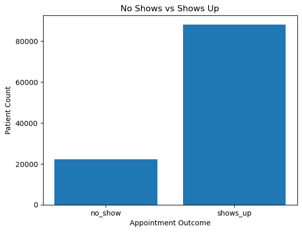

```python
no_show = df['No_show'].sum()
shows_up = df['Shows_up'].sum()

counts = [no_show,shows_up]
labels = ['no_show','shows_up']

plt.bar(labels,counts)
plt.title('No Shows vs Shows Up')
plt.xlabel('Appointment Outcome')
plt.ylabel('Patient Count')
plt.show()
```

```python
round(no_show/(shows_up+no_show),2)
```

```
0.2
```

First, I created a bar chart to visualize the comparison of patient no shows compared to when the patient shows up. I then calculated the rate of patient no shows, which came out to appoximately `20%`.

### Which factors correlate most to a patient not showing up?

```python
df['Date_diff'] = df['AppointmentDay'] - df['ScheduledDay']
df
```

|  | PatientId | Gender | ScheduledDay | AppointmentDay | Age | Neighbourhood | Scholarship | Hipertension | Diabetes | Alcoholism | Handcap | SMS_received | No_show | Shows_up | Date_diff |
| --- | --- | --- | --- | --- | --- | --- | --- | --- | --- | --- | --- | --- | --- | --- | --- |
| 0 | 29872499824296 | F | 2016-04-29 | 2016-04-29 | 62 | JARDIM DA PENHA | 0 | 1 | 0 | 0 | 0 | 0 | 0 | 1 | 0 days |
| 1 | 558997776694438 | M | 2016-04-29 | 2016-04-29 | 56 | JARDIM DA PENHA | 0 | 0 | 0 | 0 | 0 | 0 | 0 | 1 | 0 days |
| 2 | 4262962299951 | F | 2016-04-29 | 2016-04-29 | 62 | MATA DA PRAIA | 0 | 0 | 0 | 0 | 0 | 0 | 0 | 1 | 0 days |
| 3 | 867951213174 | F | 2016-04-29 | 2016-04-29 | 8 | PONTAL DE CAMBURI | 0 | 0 | 0 | 0 | 0 | 0 | 0 | 1 | 0 days |
| 4 | 8841186448183 | F | 2016-04-29 | 2016-04-29 | 56 | JARDIM DA PENHA | 0 | 1 | 1 | 0 | 0 | 0 | 0 | 1 | 0 days |
| ... | ... | ... | ... | ... | ... | ... | ... | ... | ... | ... | ... | ... | ... | ... | ... |
| 110522 | 2572134369293 | F | 2016-05-03 | 2016-06-07 | 56 | MARIA ORTIZ | 0 | 0 | 0 | 0 | 0 | 1 | 0 | 1 | 35 days |
| 110523 | 3596266328735 | F | 2016-05-03 | 2016-06-07 | 51 | MARIA ORTIZ | 0 | 0 | 0 | 0 | 0 | 1 | 0 | 1 | 35 days |
| 110524 | 15576631729893 | F | 2016-04-27 | 2016-06-07 | 21 | MARIA ORTIZ | 0 | 0 | 0 | 0 | 0 | 1 | 0 | 1 | 41 days |
| 110525 | 92134931435557 | F | 2016-04-27 | 2016-06-07 | 38 | MARIA ORTIZ | 0 | 0 | 0 | 0 | 0 | 1 | 0 | 1 | 41 days |
| 110526 | 377511518121127 | F | 2016-04-27 | 2016-06-07 | 54 | MARIA ORTIZ | 0 | 0 | 0 | 0 | 0 | 1 | 0 | 1 | 41 days |

110521 rows × 15 columns

I felt that the length of time between scheduled and appointment date could be a factor in patient no shows, so I created a column, `Date_diff`, that calculates this length for each appointment.

```python
correlation_df = df.drop(labels =['PatientId','Gender','ScheduledDay','AppointmentDay','Neighbourhood','Shows_up'], axis=1)
correlation_matrix = correlation_df.corr()
correlation_matrix
```

|  | Age | Scholarship | Hipertension | Diabetes | Alcoholism | Handcap | SMS_received | No_show | Date_diff |
| --- | --- | --- | --- | --- | --- | --- | --- | --- | --- |
| Age | 1.000000 | -0.092437 | 0.504726 | 0.292509 | 0.095862 | 0.077369 | 0.012676 | -0.060497 | 0.034804 |
| Scholarship | -0.092437 | 1.000000 | -0.019731 | -0.024899 | 0.035019 | -0.008520 | 0.001188 | 0.029150 | -0.030422 |
| Hipertension | 0.504726 | -0.019731 | 1.000000 | 0.433096 | 0.087972 | 0.080249 | -0.006309 | -0.035673 | -0.017223 |
| Diabetes | 0.292509 | -0.024899 | 0.433096 | 1.000000 | 0.018471 | 0.057629 | -0.014555 | -0.015170 | -0.027189 |
| Alcoholism | 0.095862 | 0.035019 | 0.087972 | 0.018471 | 1.000000 | 0.004689 | -0.026151 | -0.000189 | -0.038520 |
| Handcap | 0.077369 | -0.008520 | 0.080249 | 0.057629 | 0.004689 | 1.000000 | -0.024026 | -0.006381 | -0.019869 |
| SMS_received | 0.012676 | 0.001188 | -0.006309 | -0.014555 | -0.026151 | -0.024026 | 1.000000 | 0.126478 | 0.398155 |
| No_show | -0.060497 | 0.029150 | -0.035673 | -0.015170 | -0.000189 | -0.006381 | 0.126478 | 1.000000 | 0.186225 |
| Date_diff | 0.034804 | -0.030422 | -0.017223 | -0.027189 | -0.038520 | -0.019869 | 0.398155 | 0.186225 | 1.000000 |

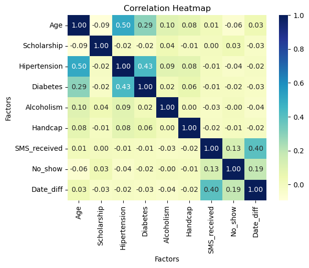

```python
sns.heatmap(correlation_matrix, annot=True, fmt=".2f", cmap='YlGnBu')
plt.title('Correlation Heatmap')
plt.xlabel('Factors')
plt.ylabel('Factors')
plt.show()
```

I dropped all unndeeded columns to create a correlation matrix and heatmap to visualize the connections. This showed that `Date_diff` and `SMS_received` had the greatest impact on if a patient would no show.

## Conclusions

Through my analysis, I found that roughly `20%` of scheduled appointments resulted in the patient not showing up. When looking at how each factor correlates to a patient no show, I found that `Date_diff` and `SMS_received` had by far the highest correlation to whether or not a patient showed up. Despite that, one limitation is that the correlation was not statisically signifcant enough to come to any conclusions. More data, such as interviewing patients about why the missed their appointment, is needed to continue this research.

## Submitting your Project

```python
# Running this cell will execute a bash command to convert this notebook to an .html file
!python -m nbconvert --to html Investigate_a_Dataset.ipynb
```

```
[NbConvertApp] Converting notebook Investigate_a_Dataset.ipynb to html
[NbConvertApp] Writing 816722 bytes to Investigate_a_Dataset.html
```